# Assignment Week 4

MinhChau

3/10/2021

Data: The World Values Survey is an ongoing worldwide survey that polls the world population about perceptions of life, work, family, politics, etc. The most recent phase of the survey that polled 77,882 people from 57 countries estimates that 36.2% of the world’s population agrees with the statement “Men should have more right to a job than women.” The survey also estimates that 13.8% of people have a university degree or higher, and that 3.6% of people fit both criteria.

##Question 1: Are agreeing with the statement “Men should have more right to a job than women” and having a university degree or higher disjoint events?

No, they are not disjoint events. Because people who have a university degree or higher are possible to agree with the statement “Men should have more right to a job than women”. Actually, P(A and B), probability of person who has a university degree or higher and agrees with the statement “Men should have more right to a job than women.”, is higher than 0.

##Question 2: Draw a Venn diagram summarizing the variables and their associated probabilities.

```r
#install.packages('VennDiagram')
library(VennDiagram)
```

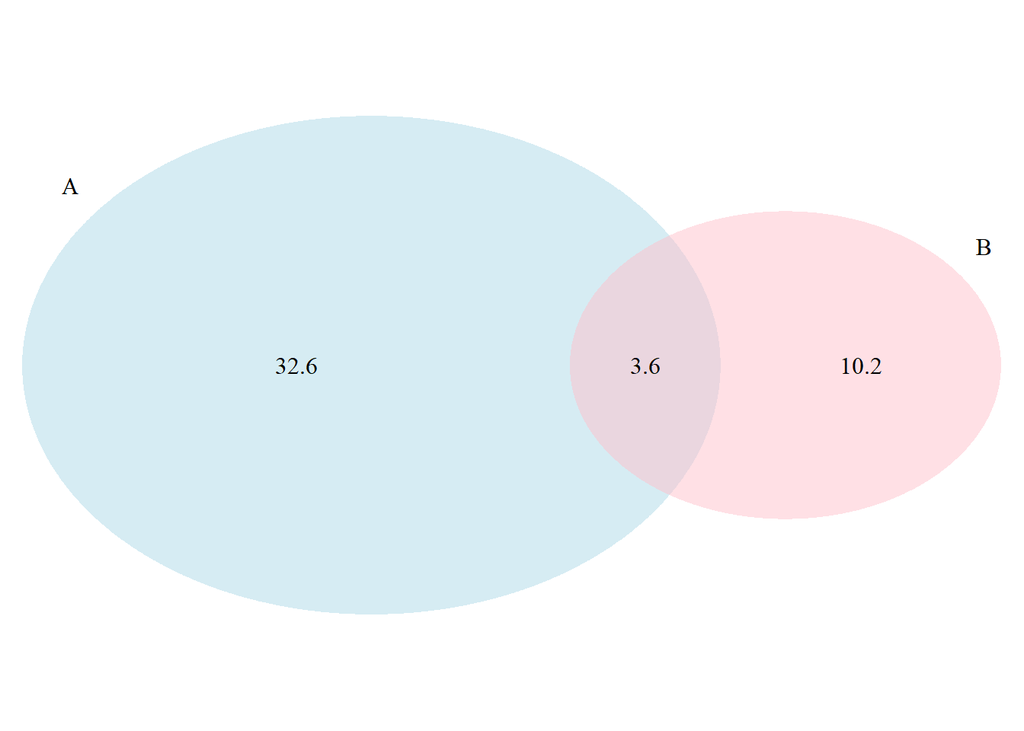

```
## (polygon[GRID.polygon.1], polygon[GRID.polygon.2], polygon[GRID.polygon.3], polygon[GRID.polygon.4], text[GRID.text.5], text[GRID.text.6], text[GRID.text.7], text[GRID.text.8], text[GRID.text.9])
```

```r
grid.newpage()
draw.pairwise.venn(area1 = 36.2, area2 = 13.8, cross.area = 3.6, category = c("A",
    "B"), lty = "blank", fill = c("light blue", "pink"))
```

##Question 3: What is the probability that a randomly drawn person has a university degree or higher or agrees with the statement about men having more right to a job than women?

P(A or B): the probability that a randomly drawn person has a university degree or higher or agrees with the statement about men having more right to a job than women

```r
p_a_or_b = p_a + p_b - p_a_and_b
p_a_or_b
```

```
## [1] 0.464
```

##Question 4: What percent of the world population do not have a university degree and disagree with the statement about men having more right to a job than women? P(no A): probability of person who does not have a university degree. It is a mutually exclusive to P(A) P(no B): probability of person who disagree with the statement about men having more right to a job than women. It is a mutually exclusive to P(B) P(no A and no B): probability of person who do not have a university degree and disagree with the statement about men having more right to a job than women

Based on the Venn diagram, we observed it this percentage represented by the outside area of two boxs. It is a mutually exclusive event of P(A or B), the probability that a randomly drawn person has a university degree or higher or agrees with the statement about men having more right to a job than women

```r
p_no_a_b = 1 - p_a_or_b
p_no_a_b
```

```
## [1] 0.536
```

##Question 5: Does it appear that the event that someone agrees with the statement is independent of the event that they have a university degree or higher? If A (the event that people a university degree or higher) and B (the event that people agree with the statement) are independent, P(A and B) must be equal to P(A).P(B). However, P(A).P(B) = 0.04995, which is different from P(A and B). Therefore, we conclude that they are not independent events.

##Question 6: What is the probability that at least 1 in 5 randomly selected people agree with the statement about men having more right to a job than women?

```r
p_Z = 1-dbinom(0, 5, 0.136)
p_Z
```

```
## [1] 0.5185306
```

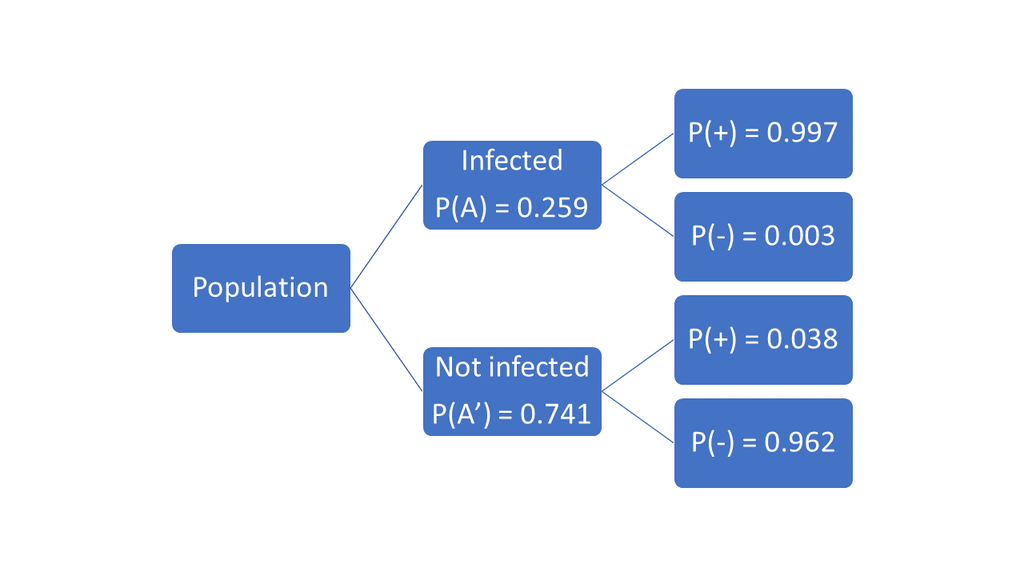

Probability Tree

##Question 7: If an individual from Swaziland has tested positive, what is the probability that he carries HIV? P(A|+) = P(A and +)/ P(+) = P(A).P(+) / (P(A).P(+) + P(A’).P(+))

```r
0.259*0.997 / ((0.259*0.997)+(0.741*0.038))
```

```
## [1] 0.9016764
```

##Question 8: According to a 2013 Gallup poll, worldwide only 13% of employees are engaged at work (psychologically committed to their jobs and likely to be making positive contributions to their organizations). Among a random sample of 10 employees, what is the probability that 8 of them are engaged at work? It is the binomal distribution with the successful probability at 0.13. Hence, we can calculate the probability of exact 8 in 10 by dbinom function, in which 10 is the number of samples.

```r
dbinom(8, 10, 0.13)
```

```
## [1] 2.77842e-06
```

##Question 9: Recent study: “Facebook users get more than they give” • friend requests: 40% made, 63% received at least one • likes: liked 14 times, had their content “liked” 20 times, on average • messages: sent 9 messages, received 12, on average • tags:12% tagged a friend in a photo, but 35% tagged other findings: 25% considered power users and average Facebook user has 245 friends P(70 or more power user friends) = ?

n: number of samples: 245 p: successful probability: 0.25 Sol 1: It is the binomal distribution with the successful probability at 0.25. Hence, we can calculate P(70 or more power user friends) by summing P(i) which i belongs to c(70:245), due to 245 is the number of samples.

```r
P_70_or_more_power_user_friends_1 = sum(dbinom(70:245, 245, 0.25))
P_70_or_more_power_user_friends_1
```

```
## [1] 0.112763
```

Sol 2: We consider the binomal distribution is aprroximately normal distribution following the success-failure rules, in which np>= 10 and n(1-p)>=10.

```r
n_9 = 245
p_9 = 0.25
mean = n_9*p_9
mean
```

```
## [1] 61.25
```

```r
SD = sqrt(n_9*p_9*(1-p_9))
SD
```

```
## [1] 6.777721
```

```r
Z = (70 - mean)/SD
Z
```

```
## [1] 1.290994
```

```r
P_70_or_more_power_user_friends_2 = 1 - pnorm(Z, 0, 1)
P_70_or_more_power_user_friends_2
```

```
## [1] 0.0983528
```

##Question 10: According to a 2014 Gallup poll, 56% of uninsured Americans who plan to get health insurance say they will do so through a government health insurance exchange. What is the probability that in a random sample of 10 people exactly 6 plan to get health insurance through a government health insurance exchange? It is the binomal distribution with the successful probability at 0.56. Hence, we can calculate the probability of exact 6 in 10 by dbinom function, in which 10 is the number of samples.

```r
dbinom(6, 10, 0.56)
```

```
## [1] 0.2427494
```